# Solutions

1. Load in the dataset, calling it `drinks_content`, and then briefly explore it, printing out: first 5 rows, last 5 rows, and then all of the data. Find out the dimensions of the data (number of rows and columns) and the column names.

```python
import pandas as pd
import numpy as np
```

```python
drinks_content = pd.read_csv("starbucks_drinkMenu_expanded.csv")
```

```python
# First 5 rows
drinks_content.head(5)
```

|  | Beverage_category | Beverage | Beverage_prep | Calories | Total Fat (g) | Trans Fat (g) | Saturated Fat (g) | Sodium (mg) | Total Carbohydrates (g) | Cholesterol (mg) | Dietary Fibre (g) | Sugars (g) | Protein (g) | Vitamin A (% DV) | Vitamin C (% DV) | Calcium (% DV) | Iron (% DV) | Caffeine (mg) |
| --- | --- | --- | --- | --- | --- | --- | --- | --- | --- | --- | --- | --- | --- | --- | --- | --- | --- | --- |
| 0 | Coffee | Brewed Coffee | Short | 3 | 0.1 | 0.0 | 0.0 | 0 | 5 | 0 | 0 | 0 | 0.3 | 0% | 0% | 0% | 0% | 175 |
| 1 | Coffee | Brewed Coffee | Tall | 4 | 0.1 | 0.0 | 0.0 | 0 | 10 | 0 | 0 | 0 | 0.5 | 0% | 0% | 0% | 0% | 260 |
| 2 | Coffee | Brewed Coffee | Grande | 5 | 0.1 | 0.0 | 0.0 | 0 | 10 | 0 | 0 | 0 | 1.0 | 0% | 0% | 0% | 0% | 330 |
| 3 | Coffee | Brewed Coffee | Venti | 5 | 0.1 | 0.0 | 0.0 | 0 | 10 | 0 | 0 | 0 | 1.0 | 0% | 0% | 2% | 0% | 410 |
| 4 | Classic Espresso Drinks | Caffè Latte | Short Nonfat Milk | 70 | 0.1 | 0.1 | 0.0 | 5 | 75 | 10 | 0 | 9 | 6.0 | 10% | 0% | 20% | 0% | 75 |

```python
# Last 5 rows
drinks_content.tail(5)
```

[output not shown]

```python
# Dimensions
drinks_content.shape
```

```
(242, 18)
```

```python
# Column names
drinks_content.columns
```

```
Index(['Beverage_category', 'Beverage', 'Beverage_prep', 'Calories',
       ' Total Fat (g)', 'Trans Fat (g) ', 'Saturated Fat (g)', ' Sodium (mg)',
       ' Total Carbohydrates (g) ', 'Cholesterol (mg)', ' Dietary Fibre (g)',
       ' Sugars (g)', ' Protein (g) ', 'Vitamin A (% DV) ', 'Vitamin C (% DV)',
       ' Calcium (% DV) ', 'Iron (% DV) ', 'Caffeine (mg)'],
      dtype='object')
```

1. We're going to be looking at the number of `Calories` in each drink. Calculate some quick summary statistics (e.g. the mean, the maximum and minimum).

```python
# Check the mean
drinks_content["Calories"].mean()
```

```
193.87190082644628
```

```python
# Check the min
drinks_content["Calories"].min()
```

```
0
```

```python
# Check the max
drinks_content["Calories"].max()
```

```
510
```

1. Select the variables Beverage_category, Beverage, Beverage prep and Calories from the `drinks_content` data frame, and assign the selected columns to a new data frame called `drinks`. Check if there are any missing values anywhere in the data, and drop any rows containing them if there are.

```python
# Select dataset with specific columns
drinks = drinks_content.loc[:, ["Beverage", "Beverage_category", "Beverage_prep", "Calories"]].copy()
```

```python
# Check if there are NA values
drinks.isna().sum()
```

```
Beverage             0
Beverage_category    0
Beverage_prep        0
Calories             0
dtype: int64
```

```python
# No missing values so no need to drop them!
```

1. In your `drinks` dataframe create a new variable (column) called `calorie_diff`, which stores the difference between 135 calories (135 calories = 10 cubes of sugar!) and the calories in each drink. (Hint: you’ll want to subtract the calories from 135 to see which drinks have more or less than 10 cubes of sugar).

```python
drinks.loc[:, "calorie_diff"] = 135 - drinks["Calories"]
drinks
```

|  | Beverage | Beverage_category | Beverage_prep | Calories | calorie_diff |
| --- | --- | --- | --- | --- | --- |
| 0 | Brewed Coffee | Coffee | Short | 3 | 132 |
| 1 | Brewed Coffee | Coffee | Tall | 4 | 131 |
| 2 | Brewed Coffee | Coffee | Grande | 5 | 130 |
| 3 | Brewed Coffee | Coffee | Venti | 5 | 130 |
| 4 | Caffè Latte | Classic Espresso Drinks | Short Nonfat Milk | 70 | 65 |
| ... | ... | ... | ... | ... | ... |
| 237 | Strawberries & Crème (Without Whipped Cream) | Frappuccino® Blended Crème | Soymilk | 320 | -185 |
| 238 | Vanilla Bean (Without Whipped Cream) | Frappuccino® Blended Crème | Tall Nonfat Milk | 170 | -35 |
| 239 | Vanilla Bean (Without Whipped Cream) | Frappuccino® Blended Crème | Whole Milk | 200 | -65 |
| 240 | Vanilla Bean (Without Whipped Cream) | Frappuccino® Blended Crème | Soymilk | 180 | -45 |
| 241 | Vanilla Bean (Without Whipped Cream) | Frappuccino® Blended Crème | Grande Nonfat Milk | 240 | -105 |

242 rows × 5 columns

1. Summarise the mean number of calories in each `Beverage_category`.

```python
# method 1
drinks.groupby("Beverage_category")["Calories"].mean()
```

```
Beverage_category
Classic Espresso Drinks              140.172414
Coffee                                 4.250000
Frappuccino® Blended Coffee          276.944444
Frappuccino® Blended Crème           233.076923
Frappuccino® Light Blended Coffee    162.500000
Shaken Iced Beverages                114.444444
Signature Espresso Drinks            250.000000
Smoothies                            282.222222
Tazo® Tea Drinks                     177.307692
Name: Calories, dtype: float64
```

1. **Harder** - Which `Beverage_prep` type contains more than the average calories of all drinks? (Hint: to answer this, you’ll have to first figure out what the average calories across all drinks are, and then use that as a filter for the grouped Beverage_prep data).

```python
# calculate mean calories across all drinks
average_cals = drinks["Calories"].mean()
average_cals
```

```
193.87190082644628
```

```python
# create a DataFrame of Beverage prep types and their mean calories
beverage_prep_cals = drinks.groupby("Beverage_prep")["Calories"].mean().reset_index(name = "mean_calories").copy()
beverage_prep_cals
```

|  | Beverage_prep | mean_calories |
| --- | --- | --- |
| 0 | 2% Milk | 218.000000 |
| 1 | Doppio | 10.000000 |
| 2 | Grande | 85.714286 |
| 3 | Grande Nonfat Milk | 209.615385 |
| 4 | Short | 37.000000 |
| 5 | Short Nonfat Milk | 99.166667 |
| 6 | Solo | 5.000000 |
| 7 | Soymilk | 207.272727 |
| 8 | Tall | 63.428571 |
| 9 | Tall Nonfat Milk | 147.826087 |
| 10 | Venti | 118.571429 |
| 11 | Venti Nonfat Milk | 260.000000 |
| 12 | Whole Milk | 283.750000 |

```python
# subset beverage prep types where mean calories is larger than avg calories of all drinks
beverage_prep_cals.loc[beverage_prep_cals["mean_calories"] > average_cals]
```

|  | Beverage_prep | mean_calories |
| --- | --- | --- |
| 0 | 2% Milk | 218.000000 |
| 3 | Grande Nonfat Milk | 209.615385 |
| 7 | Soymilk | 207.272727 |
| 11 | Venti Nonfat Milk | 260.000000 |
| 12 | Whole Milk | 283.750000 |

1. **Harder** - Which is the best type of **coffee drink** to get if you’re worried about consuming too many calories? (Hint: you can use pd.unique() on a column to get all unique values/levels of that column! Also remember that you can use isin() to subset with a list)

```python
# get unique drinks categories
pd.unique(drinks["Beverage_category"])
```

```
array(['Coffee', 'Classic Espresso Drinks', 'Signature Espresso Drinks',
       'Tazo® Tea Drinks', 'Shaken Iced Beverages', 'Smoothies',
       'Frappuccino® Blended Coffee', 'Frappuccino® Light Blended Coffee',
       'Frappuccino® Blended Crème'], dtype=object)
```

```python
# get drinks that have either the words coffee or espresso in them
coffee_drinks = drinks.loc[drinks["Beverage_category"].isin(['Coffee',
                                                             'Classic Espresso Drinks',
                                                             'Signature Espresso Drinks',
                                                             'Frappuccino® Blended Coffee',
                                                             'Frappuccino® Light Blended Coffee'])].copy()
coffee_drinks
```

|  | Beverage | Beverage_category | Beverage_prep | Calories | calorie_diff |
| --- | --- | --- | --- | --- | --- |
| 0 | Brewed Coffee | Coffee | Short | 3 | 132 |
| 1 | Brewed Coffee | Coffee | Tall | 4 | 131 |
| 2 | Brewed Coffee | Coffee | Grande | 5 | 130 |
| 3 | Brewed Coffee | Coffee | Venti | 5 | 130 |
| 4 | Caffè Latte | Classic Espresso Drinks | Short Nonfat Milk | 70 | 65 |
| ... | ... | ... | ... | ... | ... |
| 224 | Caramel | Frappuccino® Light Blended Coffee | Grande Nonfat Milk | 150 | -15 |
| 225 | Caramel | Frappuccino® Light Blended Coffee | Venti Nonfat Milk | 200 | -65 |
| 226 | Java Chip | Frappuccino® Light Blended Coffee | Tall Nonfat Milk | 150 | -15 |
| 227 | Java Chip | Frappuccino® Light Blended Coffee | Grande Nonfat Milk | 220 | -85 |
| 228 | Java Chip | Frappuccino® Light Blended Coffee | Venti Nonfat Milk | 290 | -155 |

150 rows × 5 columns

```python
coffee_drinks.sort_values("Calories").head(1)
```

|  | Beverage | Beverage_category | Beverage_prep | Calories | calorie_diff |
| --- | --- | --- | --- | --- | --- |
| 0 | Brewed Coffee | Coffee | Short | 3 | 132 |

1. Filter the dataset `drinks` so we only take "Classic Espresso Drinks", and save this in a new data frame called `espresso_drinks`.

```python
# Filter out espresso drinks
espresso_drinks = drinks.loc[drinks["Beverage_category"] == "Classic Espresso Drinks"].copy()
espresso_drinks
```

|  | Beverage | Beverage_category | Beverage_prep | Calories | calorie_diff |
| --- | --- | --- | --- | --- | --- |
| 4 | Caffè Latte | Classic Espresso Drinks | Short Nonfat Milk | 70 | 65 |
| 5 | Caffè Latte | Classic Espresso Drinks | 2% Milk | 100 | 35 |
| 6 | Caffè Latte | Classic Espresso Drinks | Soymilk | 70 | 65 |
| 7 | Caffè Latte | Classic Espresso Drinks | Tall Nonfat Milk | 100 | 35 |
| 8 | Caffè Latte | Classic Espresso Drinks | 2% Milk | 150 | -15 |
| 9 | Caffè Latte | Classic Espresso Drinks | Soymilk | 110 | 25 |
| 10 | Caffè Latte | Classic Espresso Drinks | Grande Nonfat Milk | 130 | 5 |
| 11 | Caffè Latte | Classic Espresso Drinks | 2% Milk | 190 | -55 |
| 12 | Caffè Latte | Classic Espresso Drinks | Soymilk | 150 | -15 |
| 13 | Caffè Latte | Classic Espresso Drinks | Venti Nonfat Milk | 170 | -35 |
| 14 | Caffè Latte | Classic Espresso Drinks | 2% Milk | 240 | -105 |
| 15 | Caffè Latte | Classic Espresso Drinks | Soymilk | 190 | -55 |
| 16 | Caffè Mocha (Without Whipped Cream) | Classic Espresso Drinks | Short Nonfat Milk | 110 | 25 |
| 17 | Caffè Mocha (Without Whipped Cream) | Classic Espresso Drinks | 2% Milk | 130 | 5 |
| 18 | Caffè Mocha (Without Whipped Cream) | Classic Espresso Drinks | Soymilk | 110 | 25 |
| 19 | Caffè Mocha (Without Whipped Cream) | Classic Espresso Drinks | Tall Nonfat Milk | 170 | -35 |
| 20 | Caffè Mocha (Without Whipped Cream) | Classic Espresso Drinks | 2% Milk | 200 | -65 |
| 21 | Caffè Mocha (Without Whipped Cream) | Classic Espresso Drinks | Soymilk | 180 | -45 |
| 22 | Caffè Mocha (Without Whipped Cream) | Classic Espresso Drinks | Grande Nonfat Milk | 220 | -85 |
| 23 | Caffè Mocha (Without Whipped Cream) | Classic Espresso Drinks | 2% Milk | 260 | -125 |
| 24 | Caffè Mocha (Without Whipped Cream) | Classic Espresso Drinks | Soymilk | 230 | -95 |
| 25 | Caffè Mocha (Without Whipped Cream) | Classic Espresso Drinks | Venti Nonfat Milk | 280 | -145 |
| 26 | Caffè Mocha (Without Whipped Cream) | Classic Espresso Drinks | 2% Milk | 340 | -205 |
| 27 | Caffè Mocha (Without Whipped Cream) | Classic Espresso Drinks | Soymilk | 290 | -155 |
| 28 | Vanilla Latte (Or Other Flavoured Latte) | Classic Espresso Drinks | Short Nonfat Milk | 100 | 35 |
| 29 | Vanilla Latte (Or Other Flavoured Latte) | Classic Espresso Drinks | 2% Milk | 130 | 5 |
| 30 | Vanilla Latte (Or Other Flavoured Latte) | Classic Espresso Drinks | Soymilk | 110 | 25 |
| 31 | Vanilla Latte (Or Other Flavoured Latte) | Classic Espresso Drinks | Tall Nonfat Milk | 150 | -15 |
| 32 | Vanilla Latte (Or Other Flavoured Latte) | Classic Espresso Drinks | 2% Milk | 200 | -65 |
| 33 | Vanilla Latte (Or Other Flavoured Latte) | Classic Espresso Drinks | Soymilk | 160 | -25 |
| 34 | Vanilla Latte (Or Other Flavoured Latte) | Classic Espresso Drinks | Grande Nonfat Milk | 200 | -65 |
| 35 | Vanilla Latte (Or Other Flavoured Latte) | Classic Espresso Drinks | 2% Milk | 250 | -115 |
| 36 | Vanilla Latte (Or Other Flavoured Latte) | Classic Espresso Drinks | Soymilk | 210 | -75 |
| 37 | Vanilla Latte (Or Other Flavoured Latte) | Classic Espresso Drinks | Venti Nonfat Milk | 250 | -115 |
| 38 | Vanilla Latte (Or Other Flavoured Latte) | Classic Espresso Drinks | 2% Milk | 320 | -185 |
| 39 | Vanilla Latte (Or Other Flavoured Latte) | Classic Espresso Drinks | Soymilk | 270 | -135 |
| 40 | Caffè Americano | Classic Espresso Drinks | Short | 5 | 130 |
| 41 | Caffè Americano | Classic Espresso Drinks | Tall | 10 | 125 |
| 42 | Caffè Americano | Classic Espresso Drinks | Grande | 15 | 120 |
| 43 | Caffè Americano | Classic Espresso Drinks | Venti | 25 | 110 |
| 44 | Cappuccino | Classic Espresso Drinks | Short Nonfat Milk | 50 | 85 |
| 45 | Cappuccino | Classic Espresso Drinks | 2% Milk | 80 | 55 |
| 46 | Cappuccino | Classic Espresso Drinks | Soymilk | 50 | 85 |
| 47 | Cappuccino | Classic Espresso Drinks | Tall Nonfat Milk | 60 | 75 |
| 48 | Cappuccino | Classic Espresso Drinks | 2% Milk | 90 | 45 |
| 49 | Cappuccino | Classic Espresso Drinks | Soymilk | 70 | 65 |
| 50 | Cappuccino | Classic Espresso Drinks | Grande Nonfat Milk | 80 | 55 |
| 51 | Cappuccino | Classic Espresso Drinks | 2% Milk | 120 | 15 |
| 52 | Cappuccino | Classic Espresso Drinks | Soymilk | 100 | 35 |
| 53 | Cappuccino | Classic Espresso Drinks | Venti Nonfat Milk | 110 | 25 |
| 54 | Cappuccino | Classic Espresso Drinks | 2% Milk | 150 | -15 |
| 55 | Cappuccino | Classic Espresso Drinks | Soymilk | 120 | 15 |
| 56 | Espresso | Classic Espresso Drinks | Solo | 5 | 130 |
| 57 | Espresso | Classic Espresso Drinks | Doppio | 10 | 125 |
| 58 | Skinny Latte (Any Flavour) | Classic Espresso Drinks | Short Nonfat Milk | 60 | 75 |
| 59 | Skinny Latte (Any Flavour) | Classic Espresso Drinks | Tall Nonfat Milk | 100 | 35 |
| 60 | Skinny Latte (Any Flavour) | Classic Espresso Drinks | Grande Nonfat Milk | 120 | 15 |
| 61 | Skinny Latte (Any Flavour) | Classic Espresso Drinks | Venti Nonfat Milk | 160 | -25 |

1. Group your `espresso_drinks` data frame by the type of beverage prep, and then find out the mean calories for each drink group.

```python
espresso_drinks.groupby("Beverage_prep").mean()
```

| Beverage_prep | Calories | calorie_diff |
| --- | --- | --- |
| 2% Milk | 184.375 | -49.375 |
| Doppio | 10.000 | 125.000 |
| Grande | 15.000 | 120.000 |
| Grande Nonfat Milk | 150.000 | -15.000 |
| Short | 5.000 | 130.000 |
| Short Nonfat Milk | 78.000 | 57.000 |
| Solo | 5.000 | 130.000 |
| Soymilk | 151.250 | -16.250 |
| Tall | 10.000 | 125.000 |
| Tall Nonfat Milk | 116.000 | 19.000 |
| Venti | 25.000 | 110.000 |
| Venti Nonfat Milk | 194.000 | -59.000 |

1. Get the same grouped mean `Calories` values as above, but this time sorted in descending order. (Hint: so you're able to sort the resulting groupby by the 'Calories' column you will want to ensure you get back a dataframe and not a series, so don't specify it's only `Calories` that you want to summarise, just do a groupby on all the whole dataframe and then arrange)

```python
espresso_drinks.groupby("Beverage_prep").mean().sort_values("Calories", ascending = False)
```

| Beverage_prep | Calories | calorie_diff |
| --- | --- | --- |
| Venti Nonfat Milk | 194.000 | -59.000 |
| 2% Milk | 184.375 | -49.375 |
| Soymilk | 151.250 | -16.250 |
| Grande Nonfat Milk | 150.000 | -15.000 |
| Tall Nonfat Milk | 116.000 | 19.000 |
| Short Nonfat Milk | 78.000 | 57.000 |
| Venti | 25.000 | 110.000 |
| Grande | 15.000 | 120.000 |
| Doppio | 10.000 | 125.000 |
| Tall | 10.000 | 125.000 |
| Short | 5.000 | 130.000 |
| Solo | 5.000 | 130.000 |

1. Extension: plots!

```python
import seaborn as sns
```

```python
ordered_data = drinks.groupby("Beverage_category")["Calories"].mean().sort_values(ascending = False).index
ordered_data
```

```
Index(['Smoothies', 'Frappuccino® Blended Coffee', 'Signature Espresso Drinks',
       'Frappuccino® Blended Crème', 'Tazo® Tea Drinks',
       'Frappuccino® Light Blended Coffee', 'Classic Espresso Drinks',
       'Shaken Iced Beverages', 'Coffee'],
      dtype='object', name='Beverage_category')
```

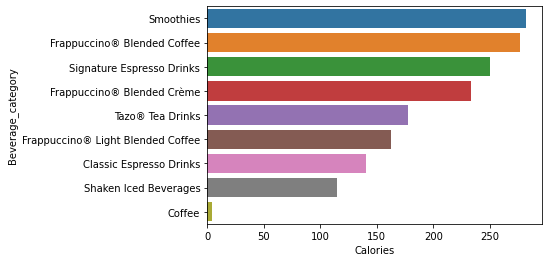

```python
sns.barplot(x = "Calories",
            y = "Beverage_category",
            data = drinks,
            ci = False,
            estimator = np.mean,
            order = ordered_data,
            orient = "h")
```